# PORSCH-AB longitudinal ordinal outcome simulations

Henri van Werkhoven

2026-07-22

## file used

patient_days_total_allresections.xlsx, tab: AB_drainage_allresections.

## Original data

Duration of (ICU) admission and mortality were analysed from 393 patients with acute pancreatitis that received antibiotics or underwent drainage (ab_drainage population).

The patients trajectory was analysed from day 0 up to day 89 (i.e. 90 days). Figure 1 shows the crude trajectory of patients. In the crude data, 18 (4.6%) patients died up to day 90. ICU admissions occurred in 163 (41.5%) patients. In these ICU-admitted patients, the mean length of ICU stay was 6.3 days (overall mean: 2.6 days). Over the follow-up time, patients spend on average 61.3 days alive out of the hospital. There were 122 readmissions (population mean: 0.310).

## Modelling

The data were modeled using a Semiparametric Ordinal Longitudinal Model (Markov model) which is based only on the follow-up day (using a spline) and the patients prior status. The model-predicted trajectory is shown in Figure 2. The model-predicted 90-day mortality rate was 4.1%. The model-predicted number of days alive out of the hospital was 61.7.

### Figure 1: crude state occupancy over time

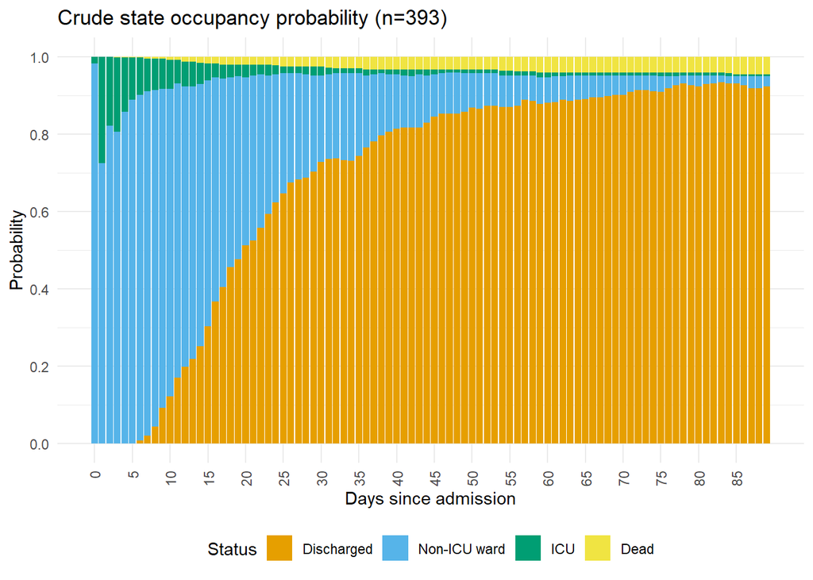

### Figure 2: model-predicted state occupancy over time

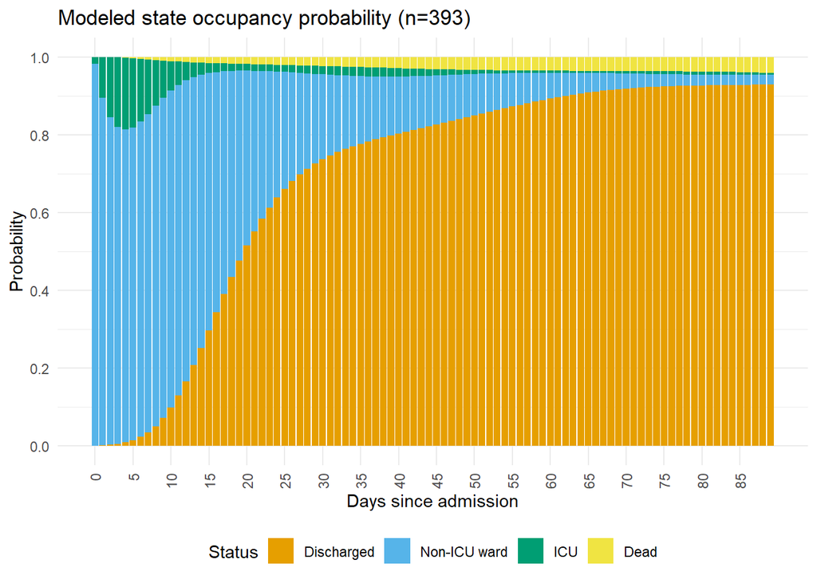

## Simulations

The model predicted mortality was lower and days alive out of hospital was higher compared to the crude data. Therefore, we applied a correction for the control group on top of the model prediction. We assumed that mortality in the trial will be the same as in the crude data in the control group (ordinal Odds Ratio [OR] of 1.038 compared to the model-predicted outcomes). With this correction, the mean simulated number of days alive out of the hospital was 60.8 in the control group. ICU admissions occurred in 54.6% of patients in the control group of the simulated data; the average number of ICU days in the total population was simulated to be 2.6. The mean number of readmissions in the simulations was 0.33 in the simulated control group.

Simulations were conducted for different longitudinal ordinal odds ratios (LOOR). Table 1 shows the implications of these LOORs for different components of the outcome. A total of 200 simulations per scenario were performed based on this model. Figure 3 shows the distributions of outcomes for the simulated scenarios.

### Table 1: effect of simulated LOORs for the components of the outcome

| LOOR | Proportional | Mortality<sup>1</sup> | Mortality RR<sup>2</sup> | ICU days<sup>3</sup> | Days alive discharged<sup>3</sup> |
| --- | --- | --- | --- | --- | --- |
| 0.800 | TRUE | -2.4% | 0.477 | -0.9 | 4.8 |
| 0.825 | TRUE | -2.2% | 0.529 | -0.8 | 4.3 |
| 0.850 | TRUE | -1.9% | 0.584 | -0.7 | 3.7 |
| 0.800 | FALSE | -1.0% | 0.782 | -1.0 | 4.2 |
| 0.825 | FALSE | -1.0% | 0.782 | -0.9 | 3.7 |
| 0.850 | FALSE | -1.0% | 0.782 | -0.7 | 3.2 |

<sup>1</sup> Absolute risk difference  
<sup>2</sup> Relative risk  
<sup>3</sup> Absolute difference

### Figure 3: simulated state occupancy over time for all scenarios

#### A

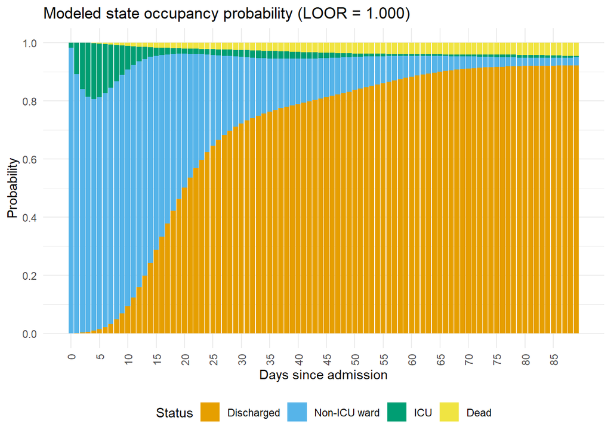

#### B

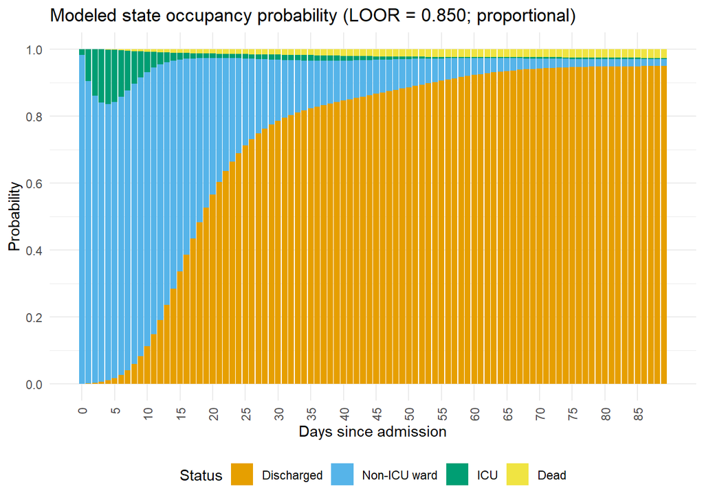

#### C

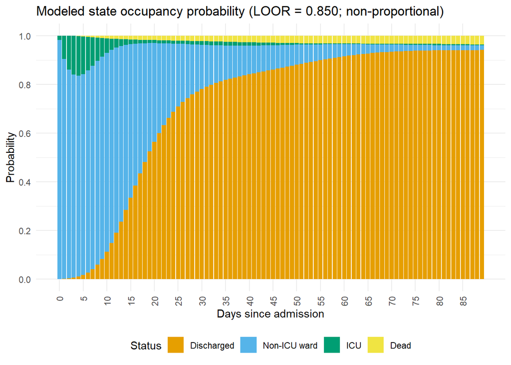

#### D

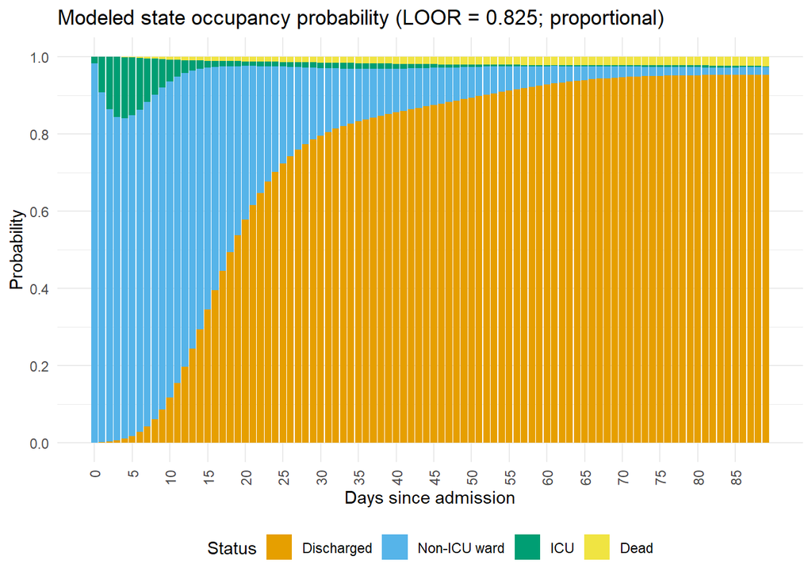

#### E

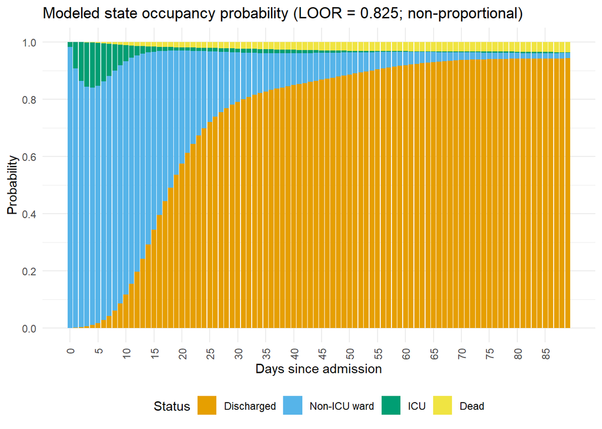

#### F

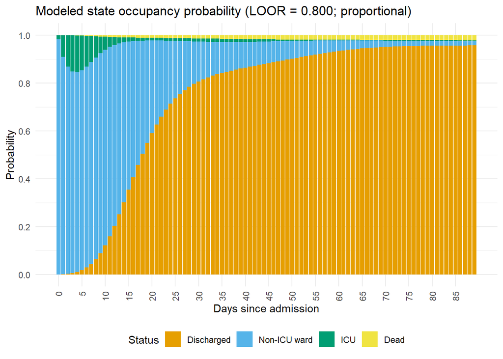

#### G

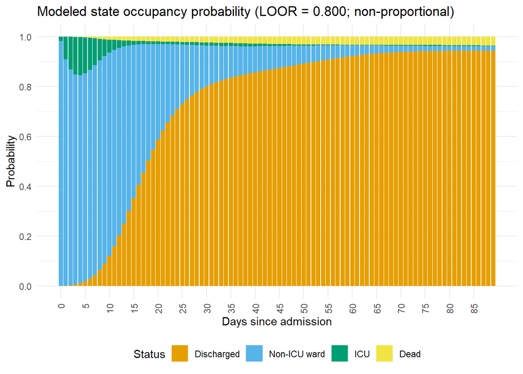

### Figure 4: power for trials with different sample size and effect size and using different endpoints. The sample sizes on the x-axis are for an individually randomized trial and they are chosen to match with the sample size expected in the stepped-wedge trial given the design effect.

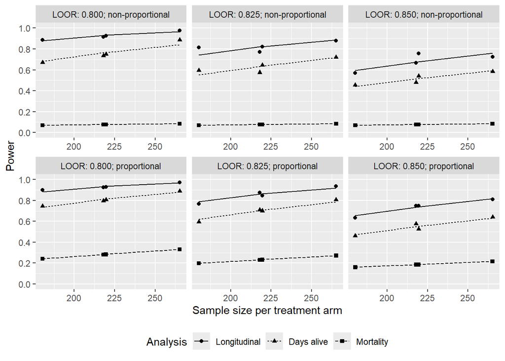

## Sample sizes for the stepped-wedge trial

*Note that a wash-in period has not been accounted for.* Introducing a wash-in will result in a somewhat reduced power, although with 4 weeks wash-in and steps of 8-10 weeks the impact will be quite limited.

### Table 2: Sample sizes for stepped-wedge trial for the longitudinal ordinal outcome.

OR.mort: assumed OR for 90-day mortality, see above. n_iRCT: sample size per arm for an individually randomized controlled trial. k: number of clusters. icc: intra-cluster correlation. DE: design effect of the stepped-wedge design. total_size: Total sample size needed for the stepped-wedge trial.

| years | enrolment | N<sup>2</sup> | DE<sup>3</sup> | Power<sup>1</sup> longitudinal ordinal | Power<sup>1</sup> days alive out of hospital |
| --- | --- | --- | --- | --- | --- |
| LOOR = 0.800 (non-proportional odds) |  |  |  |  |  |
| 2.0 | 80% | 758 | 2.102 | 87.8% | 68.1% |
| 2.0 | 100% | 948 | 2.174 | 93.0% | 76.2% |
| 2.5 | 80% | 956 | 2.177 | 93.1% | 76.5% |
| 2.5 | 100% | 1195 | 2.253 | 96.6% | 83.8% |
| LOOR = 0.825 (non-proportional odds) |  |  |  |  |  |
| 2.0 | 80% | 758 | 2.102 | 74.3% | 55.0% |
| 2.0 | 100% | 948 | 2.174 | 82.0% | 63.0% |
| 2.5 | 80% | 956 | 2.177 | 82.2% | 63.4% |
| 2.5 | 100% | 1195 | 2.253 | 88.7% | 71.5% |
| LOOR = 0.850 (non-proportional odds) |  |  |  |  |  |
| 2.0 | 80% | 758 | 2.102 | 59.3% | 44.0% |
| 2.0 | 100% | 948 | 2.174 | 67.5% | 51.2% |
| 2.5 | 80% | 956 | 2.177 | 67.8% | 51.4% |
| 2.5 | 100% | 1195 | 2.253 | 75.9% | 59.2% |
| LOOR = 0.800 (proportional odds) |  |  |  |  |  |
| 2.0 | 80% | 758 | 2.102 | 88.3% | 73.3% |
| 2.0 | 100% | 948 | 2.174 | 93.4% | 81.0% |
| 2.5 | 80% | 956 | 2.177 | 93.5% | 81.3% |
| 2.5 | 100% | 1195 | 2.253 | 96.9% | 87.9% |
| LOOR = 0.825 (proportional odds) |  |  |  |  |  |
| 2.0 | 80% | 758 | 2.102 | 79.0% | 62.0% |
| 2.0 | 100% | 948 | 2.174 | 86.0% | 70.2% |
| 2.5 | 80% | 956 | 2.177 | 86.2% | 70.5% |
| 2.5 | 100% | 1195 | 2.253 | 91.8% | 78.4% |
| LOOR = 0.850 (proportional odds) |  |  |  |  |  |
| 2.0 | 80% | 758 | 2.102 | 65.4% | 47.1% |
| 2.0 | 100% | 948 | 2.174 | 73.6% | 54.6% |
| 2.5 | 80% | 956 | 2.177 | 73.9% | 54.9% |
| 2.5 | 100% | 1195 | 2.253 | 81.5% | 62.9% |

LOOR: Longitudinal ordinal odds ratio  
<sup>1</sup> Calculated using all simulations with the same LOOR (i.e. extrapolated)  
<sup>2</sup> Total number of patients, not including a wash-in  
<sup>3</sup> Design effect